# gfwr package tool

Kilian GRIHAULT BARREIRO

2024-01-14

# How to use : Global Fishing Watch R Package (`gfwr`)

The `gfwr` package provides convenient functions to pull GFW data directly into R into usable formats.  
It contains three main functions, including `get_vessel_info()`, `get_event()` and `get_raster()`. The two first being devoted to retrieving information and features on one ore several specific vessels. The last is of particular interest to us because it allows us to gather information from global fishing watch raster on the fishing effort (further details in the function appropriate section).

The time spent fishing is computed using Automatic Identification System (AIS) data, which is transmitted by most industrial fishing vessels. The AIS data provides information on the location, speed, and direction of the vessel, which can be used to identify when the vessel is actively fishing.

#### AIS Caveats and limitations

The AIS coverage of vessels has several limitations such as :  
1. The number of vessels that are captured (AIS provides approximately 70’000 of the 2.8 million identified fishing vessels).  
2. The size of the vessels (52-85% for vessels larger than 24 meters against 1% for vessels under 12 meters).  
*Good to know: IMO mandates AIS for most vessels larger than 36 meters.*  
3. AIS interference with each other in areas of high vessel density.  
4. Some terrestrial satellites only receive messages near shore.

## Installation

```r
remotes::install_github("GlobalFishingWatch/gfwr")
```

```r
library(gfwr)
library(ggplot2)
library(tidyverse)
library(sf)
```

## API

**To access GFW APIs, you need to : 1. register for a GFW account here**

<[Shortened URL](https://tinyurl.com/2pr5nxxk)>  
2. Request API key here : https://globalfishingwatch.org/our-apis/tokens

Once you have your token, add it to your .Renviron file (by executing the chunk below), by writing (GFW_TOKEN = “YOUR_TOKEN”) in the file.  
*(You could be asked to restart R for changes to take effect.)*

```r
usethis::edit_r_environ()
```

We save the key in an object that will be used in gfwr functions.

```r
key <- gfw_auth()
```

## Fishing effort visualization

A region_id is necessary to use the `get_raster` function.

```r
region_id <- get_region_id(
  region_name = "Australia",
  region_source = "eez",
  key = key
)$id
```

The `get_raster` function gets a raster of fishing effort from the API and converts the response to a data frame which contains occurrences for each vessel and for each grid cell (data is binned into grid cells of different resolution), the `Vessel IDs`, `Flag`, `Geartype` and `Apparent fishing Hours` which are basically the amount of fishing hours of each vessel per grid cell (`geometry`).

Data can be provided through :  
- `daily`, `monthly` and `yearly` temporal resolutions.  
- `low` (0.1 deg) and `high` (0.01 deg) spatial resolutions.  
- `vessel_id`, `flag`, `gearType`, `flagAndGearType`.

```r
data <- get_raster(
  spatial_resolution = "low",
  temporal_resolution = "monthly",
  group_by = "flagAndGearType",
  date_range = "2022-01-01,2023-01-01",
  region = region_id,
  region_source = "eez",
  key = key
)
```

*(You can remove the option* `message = FALSE` *to see the columns types.)*

#### `get_raster` caveats and limitations.

Date range is limited to 1-year. Nevertheless, with some modifications, we can get round these problems through `get_gfwFishingEffort`.

#### `get_gfwFishingEffort` function.

```r
get_gfwData <- function(region, start_date, end_date, temp_res,
                        spat_res = "low",
                        key = gfwr::gfw_auth(),
                        cCRS = "EPSG:4326",
                        compress = FALSE) {
  region_id <- gfwr::get_region_id(
    region_name = region,
    region_source = "eez",
    key = key
  )$id[1]

  # Convert dates into Date objects
  start_date <- as.Date(start_date, format = "%Y-%m-%d")
  end_date <- as.Date(end_date, format = "%Y-%m-%d")

  # Function to obtain data for a specific date range
  get_data_for_range <- function(start_date, end_date) {
    date_range <- paste(start_date, end_date, sep = ",")

    data <- gfwr::get_raster(
      spatial_resolution = spat_res,
      temporal_resolution = temp_res,
      group_by = "flagAndGearType",
      date_range = date_range,
      region = region_id,
      region_source = "eez",
      key = key
    )

    return(data)
  }

  # Check whether the date range is less than or equal to 366 days
  if (as.numeric(difftime(end_date, start_date, units = "days")) <= 366) {
    # If yes, obtain data for the entire date range
    data_df <- get_data_for_range(start_date, end_date)
  } else {
    # If not, divide the date range into 366-day chunks and obtain the data for each chunk.
    date_chunks <- seq(start_date, end_date, by = "366 days")
    data_df <- purrr::map_dfr(
      date_chunks,
      ~ get_data_for_range(.x, min(.x + 365, end_date))
    )
  }

  if (isTRUE(compress)) {
    # GFW data will always be "EPSG:4326". No need to have CRS as an option here

    data_df <- data_df %>%
      dplyr::select("Lon", "Lat", "Apparent Fishing Hours") %>%
      dplyr::group_by(Lon, Lat) %>%
      dplyr::summarise("Apparent Fishing Hours" = sum(`Apparent Fishing Hours`,
        na.rm = TRUE
      )) %>%
      dplyr::ungroup()

    data_sf <- data_df %>%
      terra::rast(type = "xyz", crs = "EPSG:4326") %>% # Convert to polygons for easier use
      terra::as.polygons(
        trunc = FALSE,
        dissolve = FALSE,
        na.rm = TRUE,
        round = FALSE
      ) %>%
      sf::st_as_sf()

    if (dim(data_df)[1] != dim(data_sf)[1]) {
      stop("Data dimensions of df and sf data do not match after conversion")
    }
  } else if (isFALSE(compress)) {
    # Combine data frames in the list into one data frame
    data_df <- bind_rows(data_df)

    # Separate the "Time Range" column based on the specified temp_res
    if (temp_res == "yearly") {
      data_sf <- data_df %>%
        dplyr::mutate(Year = `Time Range`) %>%
        sf::st_as_sf(
          coords = c("Lon", "Lat"),
          crs = "EPSG:4326"
        )
    } else {
      # Sinon, séparer la colonne "Time Range" selon le temp_res spécifié
      if (temp_res == "monthly") {
        data_sf <- data_df %>%
          tidyr::separate("Time Range",
            into = c("Year", "Month"),
            sep = "-",
            remove = FALSE
          ) %>%
          sf::st_as_sf(
            coords = c("Lon", "Lat"),
            crs = "EPSG:4326"
          )
      } else if (temp_res == "daily") {
        data_sf <- data_df %>%
          tidyr::separate("Time Range",
            into = c("Year", "Month", "Day"),
            sep = "-",
            remove = FALSE
          ) %>%
          sf::st_as_sf(
            coords = c("Lon", "Lat"),
            crs = "EPSG:4326"
          )
      }
    }
  }

  # But you may wish to return the data in a different CRS. For this you need transform
  if (isFALSE(cCRS == "EPSG:4326")) {
    data_sf <- data_sf %>%
      sf::st_transform(crs = cCRS)
  }

  return(data_sf)
}
```

```r
data_sf_combined <- get_gfwData(
  region = "Australie",
  start_date = "2021-01-01",
  end_date = "2023-12-31",
  temp_res = "yearly",
  spat_res = "low",
  key = key,
  compress = FALSE
)

data_sf_combined <- get_gfwData("Australie",
  "2019-01-01",
  "2023-12-31",
  "yearly",
  compress = FALSE
)
```

## Visualization

To display the data, we load :  
- The coastline from `rnaturalearth` package and modify it to get an sf object, and we constrain it to the boundaries of the given data.  
- EEZ Polygons from _Flanders Marine Institute (2023). Maritime Boundaries Geodatabase: Maritime Boundaries and Exclusive Economic Zones (200NM), version 12. Available online at https://www.marineregions.org/. https://doi.org/10.14284/632_

```r
# Check and modify if necessary the spatial reference of data_sf_combined
data_sf_combined <- sf::st_set_crs(
  data_sf_combined,
  sf::st_crs(rnaturalearth::ne_coastline(scale = "large"))
)

coast_clipped <- rnaturalearth::ne_coastline(scale = "large") %>%
  sf::st_as_sf() %>%
  sf::st_intersection(sf::st_as_sfc(sf::st_bbox(data_sf_combined)))

# Load EEZ polygons
## Downloaded data
# eezs <- sf::st_read(dsn = '~/2024_Research_A_UQ/World_EEZ_v12_20231025/') %>%
#   sf::st_transform(crs = sf::st_crs(data_sf_combined)) %>%
#   sf::st_make_valid() %>%
#   sf::st_intersection(sf::st_as_sfc(sf::st_bbox(data_sf_combined)))

eezs <- mregions::mr_shp(key = "Australia:eez") %>%
  dplyr::filter(geoname == "Australian Exclusive Economic Zone") %>%
  sf::st_transform(crs = sf::st_crs(data_sf_combined)) %>%
  sf::st_make_valid() %>%
  sf::st_intersection(sf::st_as_sfc(sf::st_bbox(data_sf_combined)))
```

##### Raw Fishing Effort

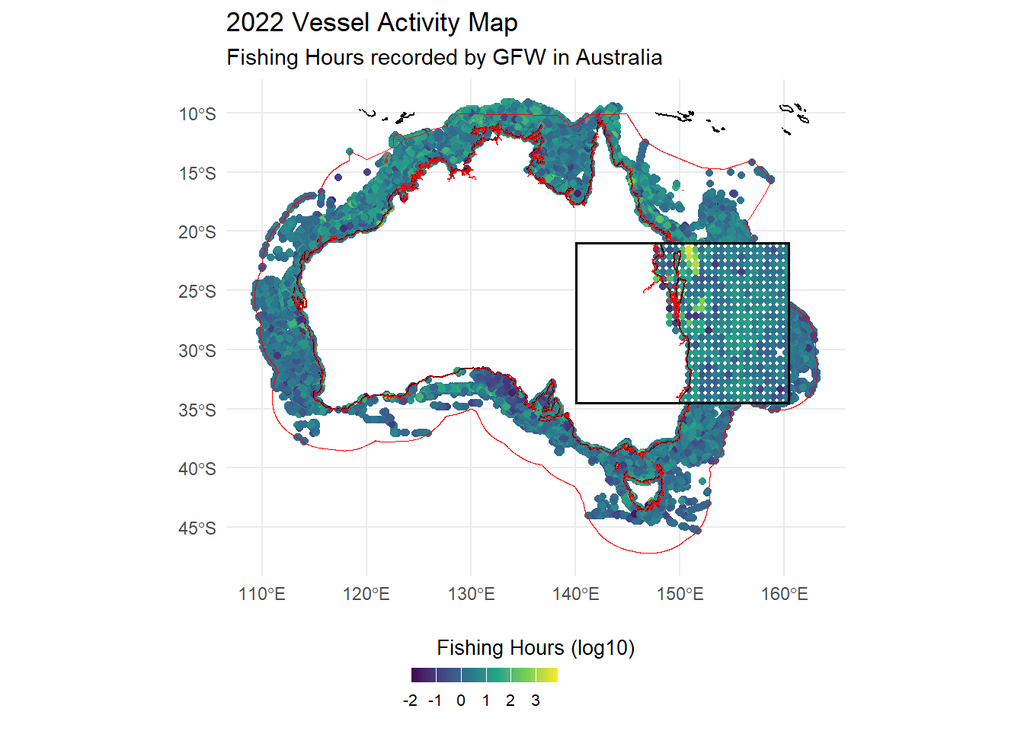

##### By years

[figure not shown]

##### Year-on-year comparison

We may need to compare different timeframes, such as seasons, to see if there are any patterns.  
**Note :** As more vessels have adopted AIS (mainly in economically developed countries) since the deployment of these technologies, the rise in activities must be seen in the context of this increase and not necessarily of more intense fishing activity.

[figure not shown]

```r
# We need to change the temporal range according to our need group by it to
# display the total fishing hours. <br>
data_sf_combined <- get_gfwData(
  "Australie",
  "2019-01-01",
  "2023-12-31",
  "monthly"
) %>%
  dplyr::group_by(Year, Month) %>%
  dplyr::summarize(Total_Fishing_Hours = sum(`Apparent Fishing Hours`))
```

##### Fishing gear type

Here we display the Vessel activity in ‘Micronesia’ in 2022 according to the fishing gear type.

```r
data_sf_combined <- get_gfwData(
  "Micronesia",
  "2022-01-01",
  "2022-12-31",
  "monthly",
  "low",
  key
)
```

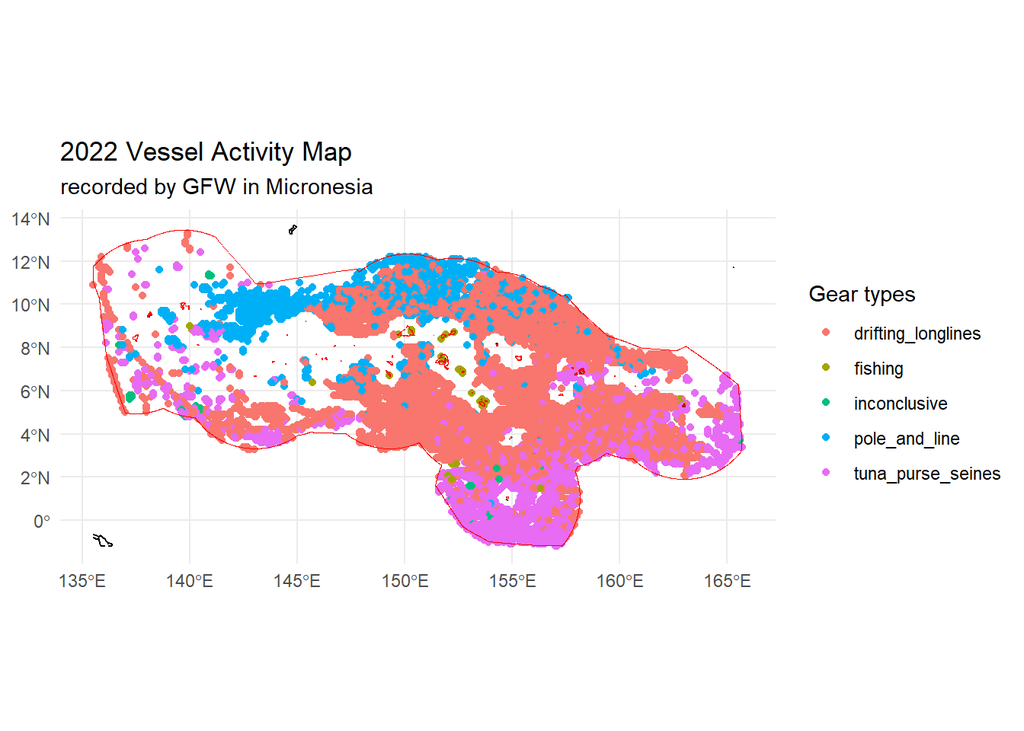

##### Flags

Here we display the Vessel activity in Papua New Guinea according to Vessels flags.

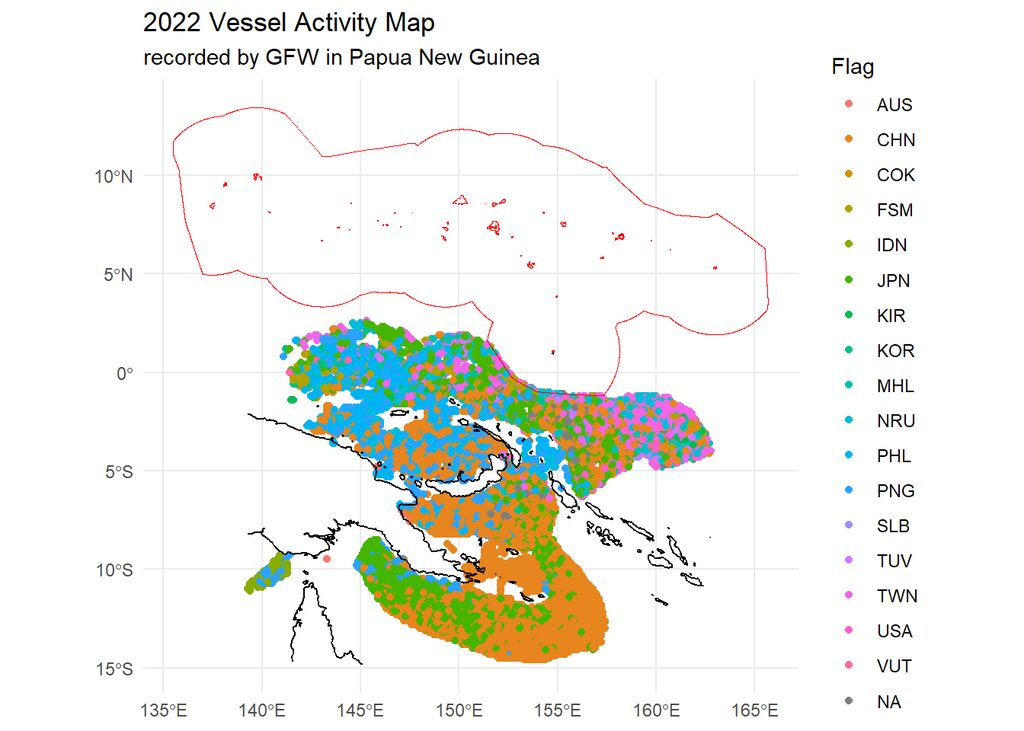

##### Supplementary materials.

The fishing detection model was trained on AIS data from 503 vessels and identified fishing activity with over 90% accuracy, which means that it can identify a fishing and non-fishing activity with high accuracy. More details on AIS operation and limitations here :  
https://globalfishingwatch.org/dataset-and-code-fishing-effort/

###### Hierarchy of vessels gear types :

https://globalfishingwatch.org/datasets-and-code-vessel-identity/*